# ESS 330 Project Proposals & Intro/Methods Draft

Authors

Leila Aburomia

Aldair Perez

Noah Goodhart

📩 *Corresponding author: Leila Aburomia

# 1.

completed by: Leila Aburomia

## Title:

Beavers’ Impact on Water Quality

## Justification:

Beavers have the ability to modify ecosystems to meet their ecological needs, profoundly impacting hydrology, geomorphology, ecology, and society. Known as ecosystem engineers, beavers and their dam building activities significantly alter water flow quality (Brazier (2020)). This project with use R to analyze how beavers influence water quality parameters such as dissolved oxygen, temperature, turbidity, and nutrient levels. In degraded environments, beavers’ dam building can improve both physical and biological diversity (Law (2016)). This diversity is essential for the functionality of many stream types (Law (2016)). Additionally, research has shown that beaver dams can help mitigate climatic hydrological extremes through their impacts on water residence time and nutrient fluxes (Dewey (2022)). Understanding how their activities influence water quality is crucial for ecosystem management, conservation, and climate resilience. Local beaver motifications can help inform hydrology decisions to increase the health and functionality of our watersheds.

## Research Objective:

The specific objective that I aim to achieve is how beaver activity influences water quality parameters. Possible hypothesizes may include; beaver-occupied streams have lower turbidity due to sediment trapping, beaver ponds reduce dissolved oxygen compared to fast-flowing streams, beaver activity increases nutrient levels due to organic matter decomposition, and beaver ponds act as temperature buffers, reducing extreme fluctuations.

## Proposed Methods:

This study will be done on a spatial scale and investigate how water quality parameters change depending on the presence of beavers. Beaver presence data can be found through Colorado Natural Heritage Program. They have a Colorado River basin Dynamic Wetland Mapper that includes beaver ponds. (https://csurams.maps.arcgis.com/apps/webappviewer/index.html?id=2fa3527926d2415d8ea0786838b712bd). Additionally, USGS has current water data for Colorado that includes many water quality parameters (https://waterdata.usgs.gov/co/nwis/rt). Variables we will use are beaver presence and water quality parameters such as nutrients and physical values. For our data analysis we will first filter data for beaver vs non- beaver sites. Our statistical tests will include summary(), and ggplot2 to visualize distributions. Then we will create boxplots to test relationships between beaver presence and water quality parameters. We will use the Shapiro-Wilk Test for Normality to test the distribution of the data and use T-Tests to compare means between the two groups (beaver vs. non-beaver).

## Expected Outcomes:

I expect to find turbidity lower in beaver - occupied sites which suggests that beaver dams trap sediment and improve water quality. I would also expect DO to be lower in beaver ponds, indicating that shower water movement and organic decay reduces oxygen levels. Lastly, I expect to find nutrient levels higher in beaver ponds, showing that organic matter accumulation influences nutrient cycling.

# 2.

completed by: Leila Aburomia

## Title:

Climate Change Impacts on Peak Flow Events in the Upper Colorado River Basin

## Justification:

This project is significant because it addresses critical challenges within climate change, hydrology, water management, and environmental sustainability. Climate change impacts of hydrology is an understudied topic. Research has shown that climate change caused alterations in the colorado river basin are likely occurring now and will increase over the next several decades (Nash (1993)). The Upper Colorado River Basin is one of the most vital watersheds in the western United States. The Colorado River supplies water to 27 million people across seven U.S states and Mexico (Gao (2011)). In the Colorado River Basin, projected runoff changes are impacted by snow cover change, temperature, and precipitation (Gao (2011)). The basin is especially sensitive to shifts in climate due to vulnerable discharge, which is exacerbated by it’s semiarid environment. Given the basin’s increasing population, need for water, and warming climate, variations in the Colorado River flows are critically important.

## Research Objective:

The project objective is to analyze how climate change is altering peak flow events in the Upper Colorado watershed using historical observations and future climate projections. The research question is as follows, How is climate change affecting the magnitude and timing of peak flow events in the Upper Colorado watershed, and what are the projected changes under future climate scenarios? The hypothesis is that Future climate projections indicate significant changes in peak flow magnitude, timing, or frequency under warming scenarios.

## Proposed Methods:

Using data from USGS Water Information System (https://waterdata.usgs.gov/nwis?) we will extract data about historical precipitation and temperature, and future temperature and precipitation projections using the climateR package. First we will identify annual peak flow events from the USGS data and use Mann-Kendall trend tests (trend package) to detect increasing/decreasing trends. Then we will compare correlations between peak flows with precipitation and temperature trends. Next we will use the CMIP6 climate projections for precipitation and temperature (climateR package) and apply hydrological models for stream flow simulations to predict how magnitudes and frequencies may change under warming climate conditions. This project will be carried on a temporal scale.

## Expected Outcomes:

Based on data, expected outcomes will include historical analysis of peak flow trends in the Upper Colorado, and projected changes in peak flows under different warming conditions. These findings are important because understanding how climate change is affecting peak flow events in the Upper Colorado watershed has critical implications for water management, ecosystem health, and flood risk assessments and mitigation.

## 3.

completed by: Aldair Perez

## Title:

The Popularity of Renewable and Non-Renewable Energy Sources in the U.S.

## Justification:

This project aims to understand how much of the U.S is coming from renewable energy and non-renewable energy The findings will present us exactly where the energy comes from, like a percentage from a source. We are currently living in a unique time where we are seeing the emergence of renewables (slow development, incentives, and technological problems) and the continued use and advancements of non-renewables, like fracking shale gas (Furlan (2017)). The rise of renewables and making non-renewables cleaner/efficient is due in part to global warming. According to empirical research, 90% of CO2 emissions are from fossil fuels (Greiner (2013)). If we want to mitigate the effects of global warming, we should implement cleaner solutions to our energy resources, like efficient cars/appliances and fracking regulations.

## Research Objective:

We will identify how much each renewable and non-renewable energy contributes to the amount of energy used in the U.S.

## Proposed Methods:

We are going to look for datasets that have the amount of energy produced by each source of energy. The timeline should be recent, so the maximum is looking at the energy production during the past 10 years. The country that will be used is the United States of America. We will calculate the total energy and find the percentage each source contributes to the total energy produced. The data used may be from this website: https://www.eia.gov/opendata/

## Expected Outcomes:

We are looking at the percentage used to give us an understanding of the popularity (or lack of popularity) for each source. The significance of this is to understand where energy is coming from since we are in a time where society is becoming more environmentally conscious.

## 4.

completed by: Aldair Perez

## Title:

The Rise and Impact of H5N1 Cases in the U.S

## Justification:

This project aims to understand the impacts of bird flu in domesticated animals, like chickens and cows. With the rise of prices of related foods, like beef, eggs, and chickens, this is causing food supply problems. In 2020, there’s an outbreak of avian influenza (H5N1) and it has spread to not only chickens, but cows (Abbasi (2024)). This is an obvious cause of concern to the food supply and human health. According to USDA, over 37 million poultry have died, chicken breast prices rose 27%, and egg prices rose 45% (Hunter (2022)). This recent outbreak, along with COVID-19, has put pressure to human and animal health as well as the state of the economy. Thus, it’s vital that we have a good understanding of the virus, the numbers, and how to respond to this outbreak.

## Research Objective:

We will identify the cases and deaths of the H5N1 virus towards animals like cows and chickens in the U.S.

## Proposed Methods:

We will look for datasets that give us information as to who has the virus infected, the cases, and deaths from the hosts (likely chickens, cows, and humans). Since this is a recent outbreak, we will look at the data from the past 5 years. We will be looking at the cases here in the U.S. We will find the dataset from these links: H5 Bird Flu: Current Situation | Bird Flu | CDC, USDA Reported H5N1 Bird Flu Detections in Poultry | Bird Flu | CDC, Avian influenza

## Expected Outcomes:

We are looking at how many cases and deaths the virus has had on chickens, cows, and people. The significance of this is to understand the extent to which the flu has impacted the populations.

## 5.

completed by: Noah Goodhart

## Title:

Urban Green Space Accessibility and Its Role in Sustainable City Development

## Justification:

Urban green spaces are critical for sustainable cities, improving biodiversity, mental health, and climate resilience (Organization (2016)). However, unequal access to green spaces worsens environmental injustice, particularly in low-income neighborhoods (Rigolon (2018)). This project assesses whether income levels correlate with green space accessibility in U.S. cities, supporting the UN Sustainable Development Goal (SDG) 11 for inclusive, sustainable urbanization.

## Research Objective:

Objective: Evaluate the relationship between neighborhood income levels and green space coverage and assess if there is a significant correlation between the two.

Hypothesis: Lower-income neighborhoods will have significantly less green space per capita than higher-income areas.

## Proposed Methods:

Datasets:

1. Green space data: NASA’s MODIS NDVI (Normalized Difference Vegetation Index) via the MODIStsp R package.
2. Income & demographic data: U.S. Census Bureau’s American Community Survey (ACS) via the tidycensus R package. Scope: 5 major U.S. cities (2015–2020). Analysis:

· Spatial mapping with sf and ggplot2.

· Correlation tests (Pearson’s r) between median income and NDVI values.

## Expected Outcomes:

We expect a positive correlation between income and green space access. The results could guide equitable urban sustainability planning.

## 6.

completed by: Noah Goodhart

## Title:

Drought Severity and Agricultural Water Use in Colorado

## Justification:

Colorado’s water resources are under increasing stress due to climate change, with the 2002–2022 period marking the driest two decades in 1,200 years (Williams (2022)). Agriculture accounts for ~80% of the state’s water use, yet drought adaptation strategies (e.g., improved irrigation) remain unevenly adopted (CWCB (n.d.)). This project evaluates whether drought severity correlates with reduced agricultural water withdrawals, supporting sustainable water management under SDG 6.

## Research Objective:

Objective: Test if drought severity (PDSI) predicts changes in agricultural water use in Colorado. Hypothesis: Counties with severe drought (PDSI ≤ −3) will show greater declines in agricultural water withdrawals compared to less-affected counties.

## Proposed Methods:

Datasets (all R-friendly): 1. Drought Data: Palmer Drought Severity Index (PDSI) for Colorado from NOAA (NCEI), accessed via rnoaa.

2. Water Use: Colorado’s Agricultural Water Use Data (CWCB) (CSV/Excel).
3. Crop Data: USDA CropScape (Colorado-specific) via the FedData package.

Scope: Colorado counties (2010–2020). Analysis:

· Time-series regression (lm()) between PDSI and water withdrawals.

· Spatial maps of drought vs. water use trends using ggplot2/sf.

## Expected Outcomes:

We anticipate counties with severe drought will show reduced agricultural water use, reflecting adaptation efforts. Results could guide policies to incentive water-efficient farming.

# Introduction & Methods Draft

## Title:

ENSO-Drought Linkages in Colorado: A Statistical Perspective

## Introduction, Background, and Motivation

Over the past decade, the western United States has experienced hydroclimatic variability that has emerged as a dominant environmental issue of great concern (Balling (2007)). Since 1996, a considerable portion of the western U.S. has seen drought conditions that are similar in scale to the historical droughts in the 1930s and 1950s (Balling (2007)). Studies have also used the paleoclimatic record to reveal evidence of long term droughts over the past 500 to 2,000 years (Woodhouse & Overpeck (1998)). Hydroclimatic variability studies range in scale from regional to watershed. This variability is often complex and may require a multitude of scales to fully understand and plan for future drought conditions. In the dry western U.S., Colorado receives less than 17 inches of average annual precipitation statewide. (Mckee (2000)). In comparison to the rest of the United States, these rainfall amounts are incredibly sparse. Luckily, Colorado’s Rocky Mountains help alleviate potential water stress by collecting more than 25 inches of precipitation annually (Mckee (2000)). By successfully adapting to this dry climate, Colorado supports a massive agricultural and recreational industry and multiple growing urban centers (Mckee (2000)). As population and industry grow, the threat of drought and its social, economic, and environmental impacts increase as well. Measuring and assessing drought accurately is essential for future planning. Historical drought data can give valuable insight into influences or indicators of drought conditions. Patterns of climatic variability that aligned with droughts in the past can help our society better prepare for the future. One of these patterns is the influential El Nino and La Nina. El Nino is caused by a warming of the tropical Pacific Ocean that occurs about every three to seven years and lasts for 12-18 months (McPhaden (2002)). La Nina is akin to El Nino with stronger than normal trade winds and cooler tropical Pacific water temperatures (McPhaden (2002)). In recent decades, the El Nino/Southern Oscillation (ENSO) has been more closely monitored, and the strength of each cycle has been documented. The effects of El Nino and La Nina on climate vary considerably across the globe, but in the western U.S., there is a pattern of impacts. During El Nino years, both extremely wet and dry conditions can be expected, while La Nina years are characterized by only dry conditions (Canon (2007)). This research aims to analyze interactions between climatic variability indicating drought and the ENSO cycle. To examine interactions between drought conditions and the El Nino/Southern Oscillation (ENSO), we will utilize a variety of climatic data. To create a framework for drought, we will use the Standardized Precipitation Index (SPI) from the National Integrated Drought Information System to measure how much observed precipitation deviated from the climatological average. This condition can be measured on a variety of time scales, indicating that the SPI can be useful for both short-term and long-term applications (NASA (n.d.)). The unit of SPI can be interpreted as “standard deviations”. We will also use the Drought Monitor of Colorado from the USDM to assess the severity and extent of drought using their standardized classification system. This data uses six classifications to characterize drought severity: normal conditions, abnormally dry (D0), and four levels of drought (D1 to D4) representing moderate, severe, extreme, and exceptional drought conditions, respectively. Lastly, we will utilize SNOTEL snowpack data from the Natural Resource Conservation Service to supplement our drought framework. In order to compare this data to ENSO cycles, we will examine El Niño and La Niña intensities for each year based on the Oceanic Nino Index (ONI). This index is the standard for NOAA used to classify El Nino and La Nina events in the eastern tropical Pacific (Null (n.d.)). Events are defined as five consecutive 3-month periods at or above the + 0.5 degrees threshold for warm (El Nino) events and at or below the - 0.5 degrees anomaly for cool (La Nina) events (Null (n.d.)). To find correlations between our drought framework and ENSO cycles, we will use R software to conduct statistical tests. First, we will preprocess our data by aligning datasets by date. For snowpack and SPI we will standardise to monthly averages and for drought monitor, we will summarize weekly data to monthly. Our statistical methods will include a correlation analysis to test correlations between ENSO index (ONI) and drought variables. We will use the Pearson correlation coefficient to measure the linear relationship. Then we will use ggplot2 to visualize the trends in a scatter plot and add a linear regression line to help visualize the relationship. If the correlation is significant, we will perform a correlation hypothesis test to provide us with the correlation coefficient and p-value. Next, we will conduct a time series analysis of cross-correlation to look for lagged effects of ENSO on drought parameters. We will also use a linear regression model to model SPI and snowpack as a function of ONI. In conclusion, these findings will help us find a relationship between El Nino/La Nina and drought in Colorado. If so, we can produce the evidence through statistical findings and visual representations, such as a scatter plot and a linear regression model. Considering we are living in a society becoming more conscious about climate change and its environmental impacts, such as more extreme drought events, this project will enforce our involvement in the understanding aspects of our global environment and comprehend to an extent on how global processes impact extreme weather.

## Exploring Data

Data for Drought 1.Measurements/Parameters: Standardized Precipitation Index (SPI) [link] To create a framework for drought, we will use the Standardized Precipitation Index (SPI) from the National Integrated Drought Information System to measure how much observed precipitation deviated from the climatological average. This condition can be measured on a variety of time scales, indicating that the SPI can be useful for both short-term and long-term applications (NASA (n.d.)). The unit of SPI can be interpreted as “standard deviations”. This data can be characterized as 9 months (1895 to present) or Paleoclimatic data (0 to 2017). SPI data can be separated by state or by county. To clean this data we will standardize monthly averages.

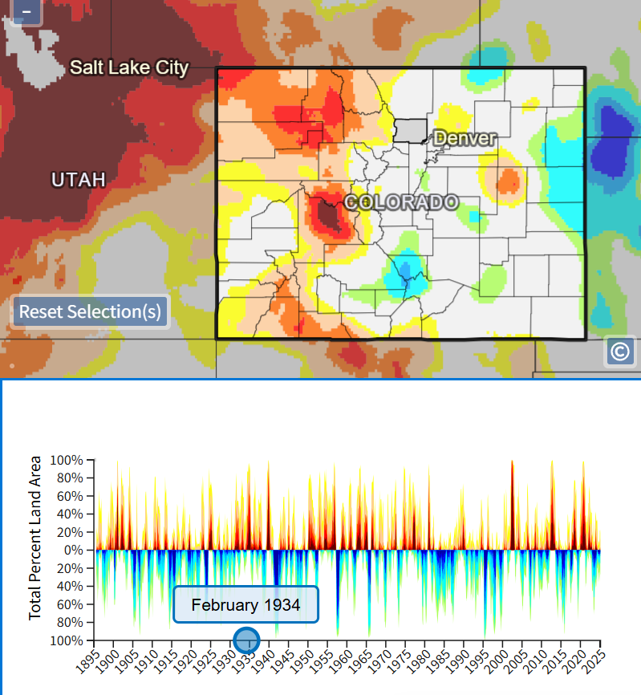

2. Drought Monitor for Colorado [link] This dataset gives us the ranking of drought intensity in the state of Colorado. The ranking ranges from none, D0-D4. The map provided has the sections that indicate counties, which are colored in respect to the drought intensity. Some of the counties have more than 1 ranking, so we have to make a consensus as to selecting the intensity for the county. There’s a table underneath explaining the week, date, and the intensity of droughts. This data will be cleaned by standardization of data by month in order to measure with our other drought parameters. - Map based on 2025. - Drought Intensity Scale (none and D0 to D4). - Includes different counties (hover for name of county).

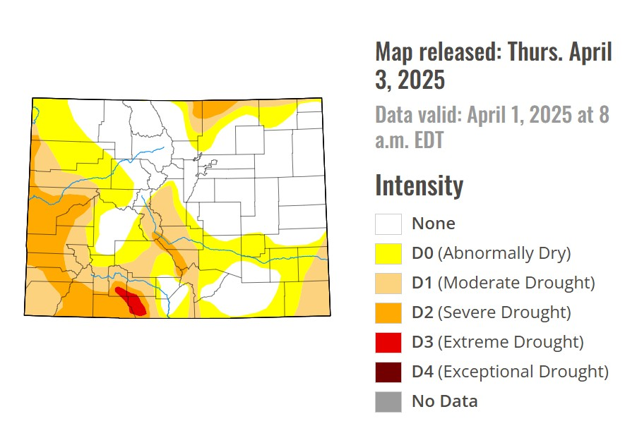

Drought Monitor for Colorado

Data for El Nino and La Nina:

1. El Nino/La Nina Intensities for each year [link] The ONI (Oceanic Nino Index) classifies El Nino/La Nina events, which runs a 3-month mean. We can categorize the strength of the event, referencing the table provided (years place in their respective event and strength). We will do some categorization of the strength as well as differentiate the events with the given data that’s provided.

## Identify your preliminary methods

For libraries we, we are most likely going to use “tidyverse” for data wrangling and visualization, “ggplot2” for graphing, “zoo” for time series data, “dplyr” for data manipulation, “tidyr” for data reshaping, “corrr” for correlation matrices, and “lmtest” for statistical tests. For our statistical analysis, we will most likely use “cor.test” to check for linear relationships between ENSO intensity and SPI, or the spearman method if we are unsure about linearity. After using “geom_boxplot” to visualize if SPI differs between El Niño, La Niña, and neutral years, we will use an Anova test to determine if the difference is significant, and then run a Tukey HSD post hoc test. Finally, to test how ENSO intensity predicts SPI, we will run a linear regression using “lm_model”. We hope to have the materials that we need. Having the 3 dataset above is a good start, and along the way, if we need more data, then we can include them. We are going to have to find a way to move the data to RStudio. Afterwards, we have to figure out the time scale for this project as to how many years we will include. Finally, we have to find a way to find out if there’s a correlation (or similar) between El Nino/La Nina and drought. We are hoping that we are able to align our datasets to make sure we can find the correlation and make a graph. We have to make sure that the datasets that we will be using can work in conjunction when it comes to the dates (month, years), SPI, snowpack, etc. If done correctly, we can proceed to do statistical analysis. The method helps us find a correlation between ONI and droughts, then perform a hypothesis test to look for correlation coefficient and p-value. We’ll also perform a linear regression model for SPI and snowpack. The findings will ensure us to find a relationship between El Nino.La Nina and drought using the dataset and using the appropriate functions to achieve those results.

## References

Abbasi, J. (2024). *Bird flu outbreak in dairy cows is widespread, raising public health concerns*. *331*(21). https://doi.org/10.1001/jama.2024.8886

Balling, G. B., R. C. & Goodrich. (2007). *Analysis of drought determinants for the colorado river basin*. *82*, 179–194. https://doi.org/10.1007/s10584-006-9157-8

Brazier, P., R. E. (2020). *Beaver: Nature’s ecosystem engineers*. *8*(1). https://doi.org/10.1002/wat2.1494

Canon, G., J. (2007). *Precipitation in the colorado river basin and its low frequency associations with PDO and ENSO signals*. *333*, 252–264. https://doi.org/10.1016/j.jhydrol.2006.08.015

CWCB, D. (n.d.). *Colorado water plan*. https://cwcb.colorado.gov/colorado-water-plan

Dewey, F., C. (2022). *Beaver dams overshadow climate extremes in controlling riparian hydrology and water quality*. *13*(6509). https://doi.org/10.1038/s41467-022-34022-0

Furlan, C., C. & Mortarino. (2017). *Forecasting the impact of renewable energies in competition with non-renewable sources*. *81*. https://doi.org/10.1016/j.rser.2017.05.284

Gao, V., Y. (2011). *Evaluating climate change over the colorado river basin using regional climate models*. *116*(D13). https://doi.org/10.1029/2010JD015278

Greiner, G., A. (2013). *Economic growth and the transition from non-renewable to renewable energy*. *19*(4). https://doi.org/10.1017/S1355770X13000491

Hunter, P. (2022). *Europe’s worst ever bird flu outbreak: Thus year’s epidemic of highly pathogenic avian flu has had a devastating impact on wild and domestic birds and severe economic consequences*. *23*(10). https://www.embopress.org/doi/full/10.15252/embr.202256048

Law, M., A. (2016). *Habitat engineering by beaver benefits aquatic biodiversity and ecosystem processes in agricultural streams*. *61*(4), 486–499. https://doi.org/10.1111/fwb.12721

Mckee, D., T. B. (2000). *A history of drought in colorado: Lessons learned and what lies ahead*. *9*. https://api.mountainscholar.org/server/api/core/bitstreams/ef0efa56-be33-419b-8a6b-db671c07ca2c/content

McPhaden, M. J. (2002). *El nino and la nina: Causes and global consequences*. *1*.

NASA. (n.d.). *Characterizing extremes over americas*. https://gmao.gsfc.nasa.gov/research/subseasonal/atlas/SPI-html/SPI-description.html

Nash, P. H., L. L. & Gleick. (1993). *The colorado river basin and climatic change*. http://www.onthecolorado.org/resources/ClimateDocs/NashGleick1993.pdf

Null, J. (n.d.). *El nino and la nina years and intensities*. https://ggweather.com/enso/oni.htm

Organization, W. H. (2016). *Urban green spaces and health*. https://iris.who.int/handle/10665/345751

Rigolon, B., A. (2018). *Inequities in the quality of urban park systems: An environmental justice investigation of cities in the united states*. *178*, 156–169. https://doi.org/10.1016/j.landurbplan.2018.05.026

Williams, C., A. P. (2022). *Rapid intensification of the emerging southwestern north american megadrought in 2020–2021*. *12*. https://doi.org/10.1038/s41558-022-01290-z

Woodhouse, C. A., & Overpeck, J. T. (1998). *2000 years of drought variability in the central united states*. *79*, 2693–2714. https://doi.org/10.1175/1520-0477(1998)079<2693:YODVIT>2.0.CO;2.